[figure not shown]

# Capítulo 1: Visualización de Datos

### Desarrollado por: Ing. Julian Quimbayo Castro

## Agenda de Trabajo

- 1. Introducción a Seaborn
- 2. Gráficas de Distribución
- 3. Gráficas para variables categóricas
- 4. Gráficas multivariables
- 5. Truco

## Objetivo de la Sesión:

- Implementar el uso de librerías para la realización de visualización de gráficos estadísticos.

## 1. Introducción a Seaborn

Seaborn es una biblioteca para hacer gráficos estadísticos en Python. Se basa en matplotlib y se integra estrechamente con las estructuras de datos de pandas.

Seaborn le ayuda a explorar y comprender sus datos. Sus funciones de trazado operan en marcos de datos y matrices que contienen conjuntos de datos completos y realizan internamente el mapeo semántico y la agregación estadística necesarios para producir gráficos informativos. Su API declarativa, orientada a los conjuntos de datos, le permite centrarse en el significado de los diferentes elementos de sus gráficos, en lugar de en los detalles de cómo dibujarlos.

Volver a Casa

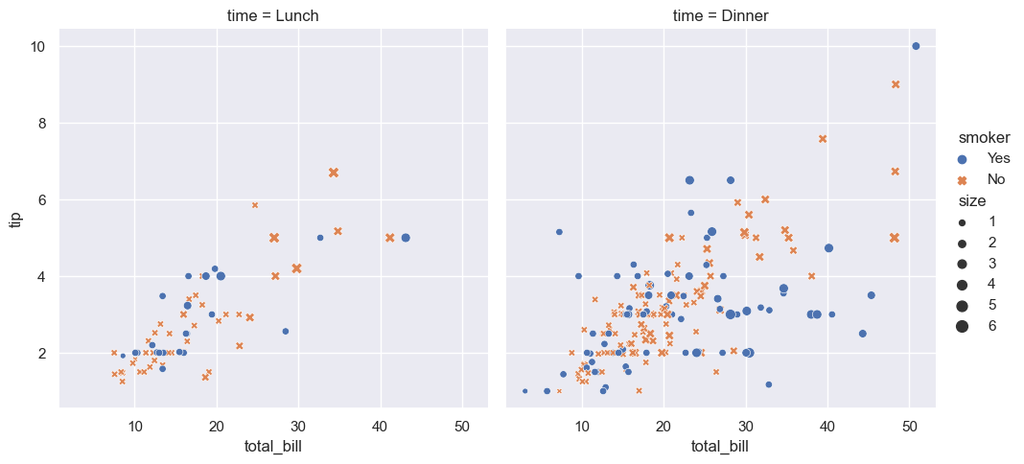

```python
# Importar librerías
import seaborn as sns

# Aplicar un tema por defecto
sns.set_theme()

# Carga de data
tips = sns.load_dataset("tips")

# Crear visualización
sns.relplot(
    data=tips,
    x="total_bill", y="tip", col="time",
    hue="smoker", style="smoker", size="size",
)
```

## 2. Gráficas de Distribución

Los análisis estadísticos requieren conocer la distribución de las variables en su conjunto de datos. La función seaborn displot() admite varios enfoques para visualizar las distribuciones. Entre ellos se encuentran las técnicas clásicas, como los histogramas, y los enfoques de cálculo intensivo, como la estimación de la densidad del núcleo.

[figure not shown]

Volver a Casa

```python
#Gráfica Uno
# sns.displot(data=tips, x="total_bill", col="time", kde=True)
#Gráficos Dos
#sns.displot(data=tips, kind="ecdf", x="total_bill", col="time", hue="smoker", rug=True)
```

## 3. Gráficas para Variables Categóricas

Varios tipos de gráficos especializados en seaborn están orientados a la visualización de datos categóricos. Se puede acceder a ellos mediante catplot(). Estos gráficos ofrecen diferentes niveles de granularidad. En el nivel más fino, puede desear ver cada observación dibujando un gráfico de "enjambre": un gráfico de dispersión que ajusta las posiciones de los puntos a lo largo del eje categórico para que no se superpongan:

[figure not shown]

Volver a Casa

```python
# Gráfica Uno:
# sns.catplot(data=tips, kind="swarm", x="day", y="total_bill", hue="smoker")

# Gráfica Dos:
#sns.catplot(data=tips, kind="violin", x="day", y="total_bill", hue="smoker", split=True)

#Gráfica Tres:
#sns.catplot(data=tips, kind="bar", x="day", y="total_bill", hue="smoker")
```

## 4. Gráficas Multivariables

Algunas funciones de seaborn combinan varios tipos de gráficos para ofrecer rápidamente resúmenes informativos de un conjunto de datos. Una de ellas, jointplot(), se centra en una única relación. Traza la distribución conjunta entre dos variables junto con la distribución marginal de cada una de ellas:

[figure not shown]

Volver a Casa

```python
#penguins = sns.load_dataset("penguins")
#sns.jointplot(data=penguins, x="flipper_length_mm", y="bill_length_mm", hue="species")
```

## 5. Truco

[figure not shown]

Más información sobre los temas tratados en el siguiente repositorio de Git: Visualizacion Taller encontrarás el resumen en codigo Python 3.10.